# RFM Customer Segmentation in Python and Spark | by Xhentilo Karaj | Towards Data Science

·

# RFM Customer Segmentation in Python and Spark

Xhentilo Karaj

Sep 13, 2019·6 min read

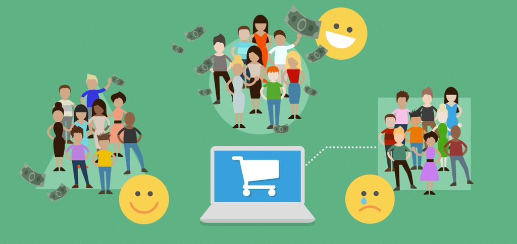

[Source](https://www.blastam.com/blog/rfm-analysis-boosts-sales)

**RFM segmentation** is a great method to divide customers into equal groups depending on three criteria (which compose the RFM acronym):

- **Recency**. How much time has elapsed since a customer’s last activity or transaction with the company?
- **Frequency**. How often has a customer transacted with the company during a particular period of time?
- **Monetary**. How much a customer has spent with the brand during a particular period of time.

In this article, we will see how customers can be segmented in different segments along with the code in Apache Spark. The latter does not need any introduction anymore; it has become the **de-facto big data platform** of this decade and we shall leverage some of its basic, yet profound capabilities.

We will use Python as a programming language for interacting with Spark. Python is becoming the lingua franca of the data analysis field and therefore it makes sense to perform the RFM customer segmentation in that language.

Let’s get started.

# 1 Setting Up the Environment

We will be using the Jupyter Notebook application in order to perform the RFM segmentation in Spark. To be able to use Spark in our notebook, we need to import the `findspark` package as well as the `pyspark` module and its `sql` module’s components:

[interactive chart not shown]

Subsequently, we create a `SparkSession` to interact with Spark. SparkSession is a unified entry point of a Spark application.

[interactive chart not shown]

To make sure that the Spark connection is alright, we call the spark variable and check the output:

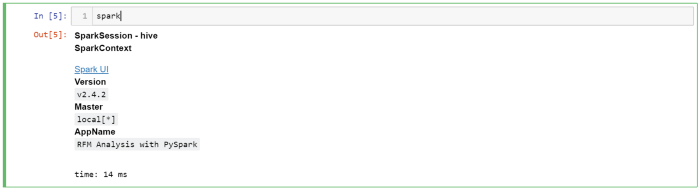

Now we should be all set and may start our journey towards RFM analysis.

# 2 About the dataset

In this article, we will use an e-commerce dataset which contains transactions for a UK-based and registered non-store online retail from 2010 to 2011 and is provided freely from The UCI Machine Learning Repository. You can download the data [here](https://www.kaggle.com/carrie1/ecommerce-data).

The dataset contains the following relevant columns needed for our analysis:

- *InvoiceNo*. Unique id for each sale.
- *StockCode*. Unique id for each product.
- *Quantity*. Number of units bought.
- *InvioceDate*. Date of the sale.
- *UnitPrice*. Retail price of the product.
- *CustomerID*. Unique id for each customer.

# 3 Preprocessing Data

Data preprocessing is one of the most important, yet tedious tasks in data science. Most data scientists spend only 20 percent of their time on actual data analysis and 80 percent of their time finding, cleaning, and reorganizing.

We begin by loading the CSV file into a Spark DataFrame, by using the Spark’s `read` method, where we specify the format of the file as well as whether the file contains a header:

[interactive chart not shown]

By calling Spark’s `printSchema` method, we inspect the data types for each column of the CSV file:

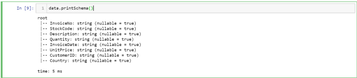

Since we did not instruct Spark on the column’s datatypes, it has assumed that they are all strings. However, it is necessary to change the data type of several columns which are needed on our subsequent analysis, namely: Quantity, UnitPrice, Date. We also have to add two new calculated columns:

- **Total**, which is equal to UnitPrice * Quantity. It is needed to calculate the monetary value of each customer.
- **RecencyDays**, which is a measure that tells the difference in days between the 31st of December 2011 (which we have chosen as the day of reference) and the InvoiceDate.

Spark has an important feature of being able to add new calculated columns to an existing DataFrame. This is done through its `withColumn` method. A special case of this method is when we want to change current columns and this is done by putting the column’s name at the first parameter of the method.

[interactive chart not shown]

# 4 Creation of RFM Table

Now that we have preprocessed our data, the creation of the RFM table is quite straightforward. For each customer, we need to measure the following indicators:

- *Recency*. We shall consider as recency the minimum RecencyDays that we calculated in the previous step. This makes sense since the minimum RecencyDays will give us the number of days that have passed since the customer’s last purchase.
- *Frequency*. It is calculated as the number of purchases that the customer has made.
- *Monetary*. It is the total value of all purchases for each customer.

[interactive chart not shown]

The new rfm_table DataFrame contains the RFM indicators for each customer.

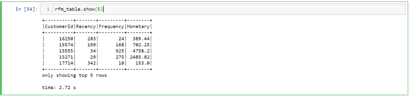

We are not yet ready to perform our RFM analysis. Before we go into that, we should first compute some meaningful scores for each RFM indicator. We are assigning a score ranging from 1 to 4 to each customer, where 1 denotes the lowest score while 4 is the highest score. Obviously, the customer who has 4s at all indicators is considered the best customer.

Since we are assigning scores from 1 to 4, we can divide the RFM values based on statistical quartiles. The following code in PySpark performs the necessary operations to calculate the quartiles and create three new columns in the RFM table that correspond to the RFM scores. In the end, we concatenate the RFM scores into a single column in order to have an instant view of the customer’s typology.

[interactive chart not shown]

Let’s take a look at the final version of the RFM table now:

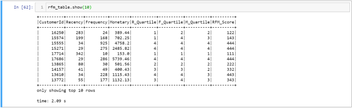

# 5 RFM Analysis

We can now easily query our RFM table for relevant business questions. Want to find out who are the best customers? Easy stuff:

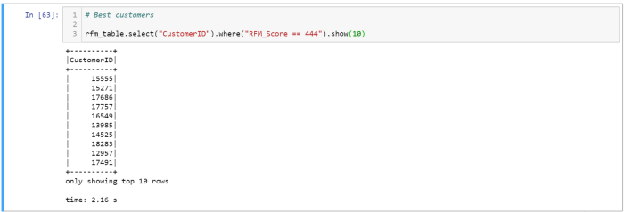

We can segment our customers based on the RFM score and then find the number of customers within each segment. In order to visualize that metric, we would need to convert our Spark DataFrame into a Pandas DataFrame. This is comfortably done by using Spark’s `toPandas` method. Finally, we are going to visualize the number of customers per each segment in a bar chart by using [Plotly](https://plot.ly/python/), which is an interactive data visualization library.

[interactive chart not shown]

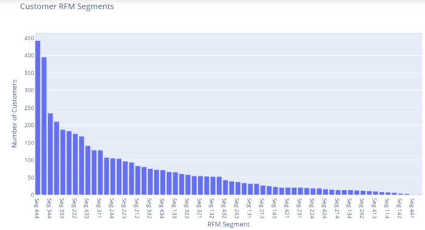

Surprisingly, the best customers compose the largest segment :), but ironically the worst customers (customers with all scores of 1s) are the second-largest segment :(.

Apart from the best and worst customers, we may also define the following important customer segments:

- **High-spending New Customers** — This group consists of those customers in 4–1–3 and 4–1–4. These are customers who transacted only once, but very recently and they spent a lot.
- **Lowest-Spending Active Loyal Customers** — This group consists of those customers in segments 3–4–1 and 4–4–1 (they transacted recently and do so often, but spend the least).
- **Churned Best Customers** — This segment consists of those customers in groups 1–3–3, 1–4–3, 1–3–4 and 1–4–4 (they transacted frequently and spent a lot, but it’s been a *long* time since they’ve transacted).

Deciding which groups of customers to target and how to best communicate with them is where the art of marketing comes in.

# Conclusion

You have reached the end of this article. We covered a lot of details about Customer Segmentation all the while writing code in PySpark. Please go to my [Github](https://github.com/xhentilokaraj/rfm-spark) repository to access the notebook code of this article.

Thank you for reading.

*Since this is my first article on Medium, I would highly appreciate any useful feedback.*

## Xhentilo Karaj

BI & Data Analyst; Aspiring Data Scientist

Follow

### By Towards Data Science

- [Data Science](https://towardsdatascience.com/tagged/data-science)
- [Spark](https://towardsdatascience.com/tagged/spark)
- [Python](https://towardsdatascience.com/tagged/python)
- [Data Visualization](https://towardsdatascience.com/tagged/data-visualization)
- [Analytics](https://towardsdatascience.com/tagged/analytics)

Follow

Your home for data science. A Medium publication sharing concepts, ideas and codes.

Ruta Gokhale

·Sep 13, 2019

[figure not shown]

The Office — Season 5, Episode 17 — Golden Ticket